# Comparisons Between Groups

TEMBA Statistics 2026

## Two coding bootcamps

An invented study independently samples employees who completed each program and gives them the same coding exercise.

| Program | Employees | Mean score | SD |
| --- | --- | --- | --- |
| Intensive | 70 | 129 | 20 |
| Standard | 50 | 120 | 25 |

How large is the difference in population mean scores, **intensive minus standard**?

## Standard error of the difference

Let A denote the intensive program and B the standard program. For independent samples,

$$SE(\bar X_A-\bar X_B)\approx
\sqrt{\frac{s_A^2}{n_A}+\frac{s_B^2}{n_B}}.$$

$$\widehat{SE}=\sqrt{\frac{20^2}{70}+\frac{25^2}{50}}
\approx 4.27\text{ points}.$$

Errors in either sample mean contribute to the error in their difference, so the variances add.

## The difference in mean scores

$$\bar x_A-\bar x_B=129-120=9\text{ points}.$$

The approximate 95% interval is

$$9\pm2(4.27)
\approx[0.5,\ 17.5]\text{ points}.$$

The intensive group’s mean could be about half a point to 17.5 points higher.

## Testing equal means

$$H_0:\mu_A-\mu_B=0,\qquad H_A:\mu_A-\mu_B\ne0.$$

Either program could have the higher population mean, so we use a **two-sided test**.

$$t=\frac{(\bar x_A-\bar x_B)-0}{SE(\bar X_A-\bar X_B)}
=\frac{9}{4.27}
\approx 2.11.$$

The observed difference is about 2.11 standard errors above zero.

## A two-sided p-value

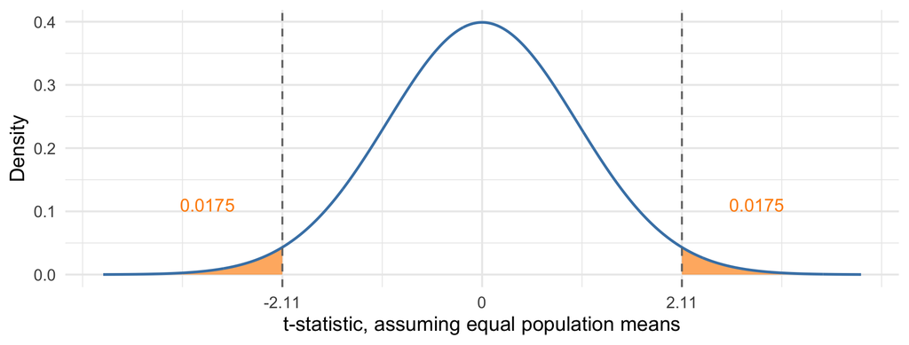

$$\text{p-value}=\Pr(T\leq-2.11)+\Pr(T\geq2.11)\approx 0.035.$$

## Intervals for the comparison

| Quantity | Approximate 95% interval |
| --- | --- |
| Intensive mean | [124.2, 133.8] |
| Standard mean | [112.9, 127.1] |
| Intensive minus standard | [0.5, 17.5] |

The separate intervals overlap, but the interval for the difference excludes zero.

A question about a difference needs the interval for that difference.

## How employees entered the programs

What would happen to the comparison if:

- Stronger employees chose the intensive program?
- Managers sent weaker employees to the intensive program?

Random assignment prevents those characteristics from systematically determining which program employees receive.

## Paired observations

Each employee takes the test before and after training:

$$d_i=\text{score after}_i-\text{score before}_i.$$

For $n$ employees, let $s_d$ be the SD of their score changes. Apply the one-sample SE and interval to those changes:

$$\widehat{SE}(\bar d)=\frac{s_d}{\sqrt n},\qquad
\bar d\pm2\frac{s_d}{\sqrt n}.$$

This interval assumes independent employees and an adequate normal approximation for the mean change.

## Two suppliers

An invented evaluation independently samples and inspects 15,000 parts from each supplier.

| Supplier | Defective | Inspected | Defect rate |
| --- | --- | --- | --- |
| A | 180 | 15,000 | 1.2% |
| B | 120 | 15,000 | 0.8% |

$$\hat p_A-\hat p_B=0.012-0.008=0.004.$$

Supplier A’s observed defect rate is **0.4 percentage points higher**.

## Standard error for two proportions

For independent samples,

$$SE(\hat p_A-\hat p_B)\approx
\sqrt{\frac{\hat p_A(1-\hat p_A)}{n_A}
+\frac{\hat p_B(1-\hat p_B)}{n_B}}.$$

$$\widehat{SE}=\sqrt{\frac{0.012(0.988)}{15{,}000}
+\frac{0.008(0.992)}{15{,}000}}
\approx 0.001149.$$

That is about **0.115 percentage points**.

## The difference in defect rates

The approximate 95% interval, in percentage points, is

$$0.4\pm2(0.115)
\approx[0.17,\ 0.63].$$

For $H_0:p_A-p_B=0$ against $H_A:p_A-p_B\ne0$,

$$t=\frac{0.004}{0.001149}
\approx 3.48,\qquad
\text{p-value}<0.001.$$

The data support a higher defect rate for A. Should the company switch to B?

## The cost of switching

| Item | Amount |
| --- | --- |
| Supplier A’s price | $12 per part |
| Supplier B’s price | $15 per part |
| Annual purchases | 50,000 parts |
| Cost per defective part | $450 |

What is B’s annual price premium? What would A’s estimated excess defects cost?

## Annual costs

| Quantity | Calculation | Amount |
| --- | --- | --- |
| B’s price premium | $50{,}000\times(15-12)$ | $150,000 |
| A’s excess defects | $50{,}000\times0.004$ | 200 parts |
| Cost of those defects | $200\times450$ | $90,000 |

At the estimated defect-rate difference, staying with A saves **$60,000 per year**.

## The break-even difference

Switching pays if the reduction in defect costs exceeds the $150,000 premium.

$$\text{Break-even difference}
=\frac{150{,}000}{450\times50{,}000}
\approx0.006667.$$

B needs a defect-rate advantage above **0.667 percentage points**.

## The interval and break-even

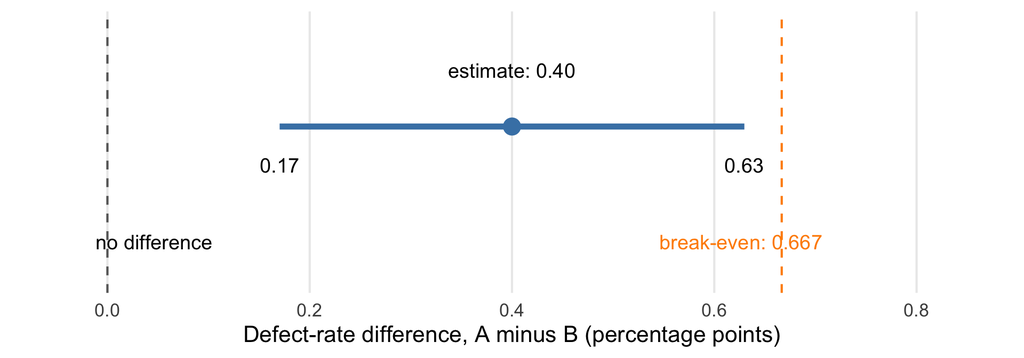

Even at the upper endpoint, excess defects cost about **$141,700**, below B’s premium.

## An A/B test

An e-commerce site randomly assigns visitors to two page designs. Count a purchase as a conversion.

| Variant | Conversions | Visitors |
| --- | --- | --- |
| A | 156 | 820 |
| B | 171 | 830 |

Using these invented counts, construct an approximate 95% interval for the conversion-rate difference, **B minus A**.

What does the interval tell us about B? What else would you need to decide whether to switch?

## The conversion-rate difference

$$\hat p_B-\hat p_A=\frac{171}{830}-\frac{156}{820}
\approx 0.0158.$$

$$0.0158\pm2(0.0196)
\approx[-0.023,\ 0.055].$$

The approximate 95% interval for B’s conversion rate minus A’s runs from $-2.3$ to $5.5$ percentage points.

Against zero, $t\approx 0.8$ and the two-sided p-value is about 0.42. The data leave both directions plausible.

## Standard errors

| Parameter | Estimate | Estimated SE |
| --- | --- | --- |
| Mean | $\bar x$ | $s/\sqrt n$ |
| Proportion | $\hat p$ | $\sqrt{\hat p(1-\hat p)/n}$ |
| Difference in means | $\bar x_A-\bar x_B$ | $\sqrt{s_A^2/n_A+s_B^2/n_B}$ |
| Difference in proportions | $\hat p_A-\hat p_B$ | $\sqrt{\hat p_A(1-\hat p_A)/n_A+\hat p_B(1-\hat p_B)/n_B}$ |

These formulas assume iid observations within each group and independent groups. For paired observations, use the mean row on the within-pair differences.

With an adequate normal approximation,

$$\text{Approximate 95\% CI}:\quad\text{estimate}\pm2SE$$

$$t=\frac{\text{estimate}-\text{hypothesized value}}{SE}.$$